# Progress Memo 1

Final Project  
Data Science 2 with R (STAT 301-2)

Author

Lily Ng

Published

February 4, 2024

**Github Repo Link**

[Final Project 2 GitHub Repo](https://github.com/stat301-2-2024-winter/final-project-2-lilyng3.git)

## Prediction Problem

My final project will research what factors affect students either dropping out or attainment of an educational degree. The variable I will be focusing on is the student’s enrollment status (dropped out, or enrolled/graduated), therefore this problem is a classification problem. Having a prediction model to predict factors that influence students dropping out or staying in school is relevant as educational institutions prioritize retaining students. Additionally, it is important for students to achieve a degree if possible as holding a degree correlates with more privilege in life. This is particularly interesting to me as I study education, and I thought the pieces of data they collected from each student, such as information on their parents, if they have a scholarship, and if they are displaces, among other things, are particularly interesting potential predictors to study.

## Data source

My data source is from the UCI Machine Learning Repository, which provides high quality and well used datasets for machine learning purposes. This dataset explores the enrollment status of students in higher education, and provides information about them such as their area of study, demographic and background information, and their academic performance.

I have also cited the paper, *Early Prediction of student’s Performance in Higher Education: A Case Study,* as it was requested to do alongside the usage of the data.

**Dataset:**

Valentim Realinho, M. V. M. (2021). Predict students’ dropout and academic success [dataset]. UCI Machine Learning Repository. https://doi.org/10.24432/C5MC89

**Paper:**

Martins, M. V., Tolledo, D., Machado, J., Baptista, L. M. T., & Realinho, V. (2021). Early Prediction of student’s Performance in Higher Education: A Case Study. In Á. Rocha, H. Adeli, G. Dzemyda, F. Moreira, & A. M. Ramalho Correia (Eds.), Trends and Applications in Information Systems and Technologies (Vol. 1365, pp. 166–175). Springer International Publishing. https://doi.org/10.1007/978-3-030-72657-7_16

## Data quality check

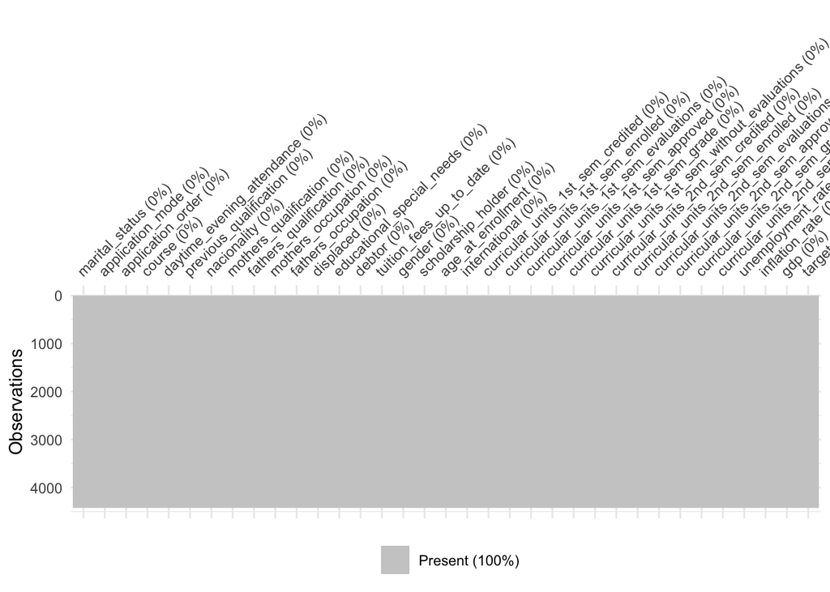

## Target variable analysis

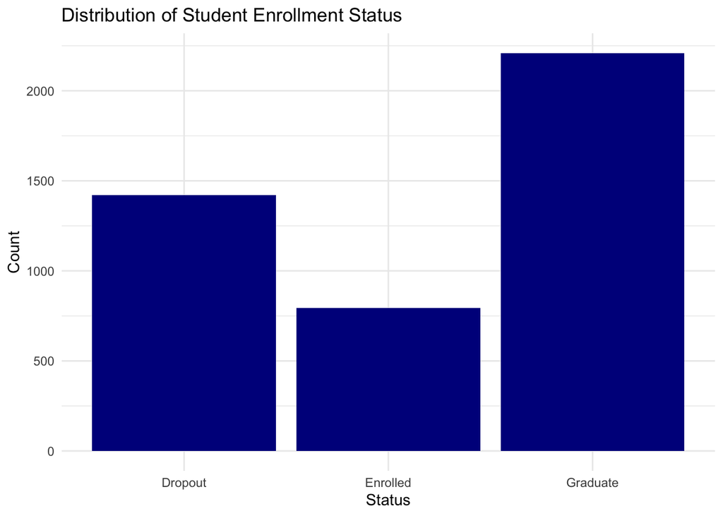

## Misc

Considering the data is mostly communicated with integers, I will change some of the data into corresponding factors, but I will also leave some of them as integers and then interpret from there if there are too many levels. My current plan is to convert the variables with only a few options to character variables, and then keep the other character variables that have 100+ values as integers. I will likely not use the ones with too many variables as predictors, as they have too wide of a range.